# HOMEWORK 4

Duygu Kaya - IE582 - Fall 2020

The aim is to compare the performance of penalized regression approaches, decision trees and tree-based ensembles by using four datasets for a classification task from different domain.The datasets are taken from UCI Machine Learning repository.All datasets have more than 20 features and separate labeled test data.The performance of the algorithms are measured for specified parameters and results are compared.

## DATASET 1 : SPORT ARTICLES FOR OBJECTIVITY ANALYSIS

The dataset consists two classes that are subjective and objective to classify sports articles by using different features such as frequency of comparative adjectives,singular common nouns and first person pronouns.Some of the features are removed such as ID,URL etc.There is no class imbalance.Test data is obtained from 20% of the training data and 10% of the data is used as a cross-validation data to measure algorithms for different samples.

- Classification
- 59 features
- 1000 instances
- Numerical features

```r
# SPORTS ARTICLES for OBJECTIVITY ANALYSIS

library(tidyverse)
library(dplyr)
library(stringr)
library(glmnet)
library(stats)
library(base)
library(caret)
library(rpart)
library(rattle)
library(readxl)
library(Metrics)
library(penalized)
library(randomForest)
library(gbm)

sports <- read_xlsx("C:\\Users\\kayad\\Desktop\\sports_data.xlsx")
sports <- subset(sports,select=-c(TextID,URL,NNP,ellipsis,WRB))

# train and test data

# 80% of the sample size
smp_size <- floor(0.8 * nrow(sports))

set.seed(123)
train_ind <- sample(seq_len(nrow(sports)), size = smp_size)

sport_training <-sports[train_ind, ]
sport_test <- sports[-train_ind, ]

# cv data

sport_training<-sport_training[sample(nrow(sport_training)),]

folds <- cut(seq(1,nrow(sport_training)),breaks=10,labels=FALSE)
for(i in 1:10){
  testIndexes <- which(folds==i,arr.ind=TRUE)
  sport_cv <- sport_training[testIndexes, ]
  sport_train <- sport_training[-testIndexes, ]
}

prop.table(table(sport_train$Label))
```

```
##
##  objective subjective
##  0.6361111  0.3638889
```

```r
prop.table(table(sport_cv$Label))
```

```
##
##  objective subjective
##     0.6875     0.3125
```

```r
prop.table(table(sport_test$Label))
```

```
##
##  objective subjective
##       0.61       0.39
```

### PENALIZED REGRESSION APPROACH

Penalized regression approaches with lasso penalty is applied for different lambdas as a tune parameter.Binary classification is used. PRA can be useful to avoid overfitting and performing variable selection in order to reduce the complexity of the model.

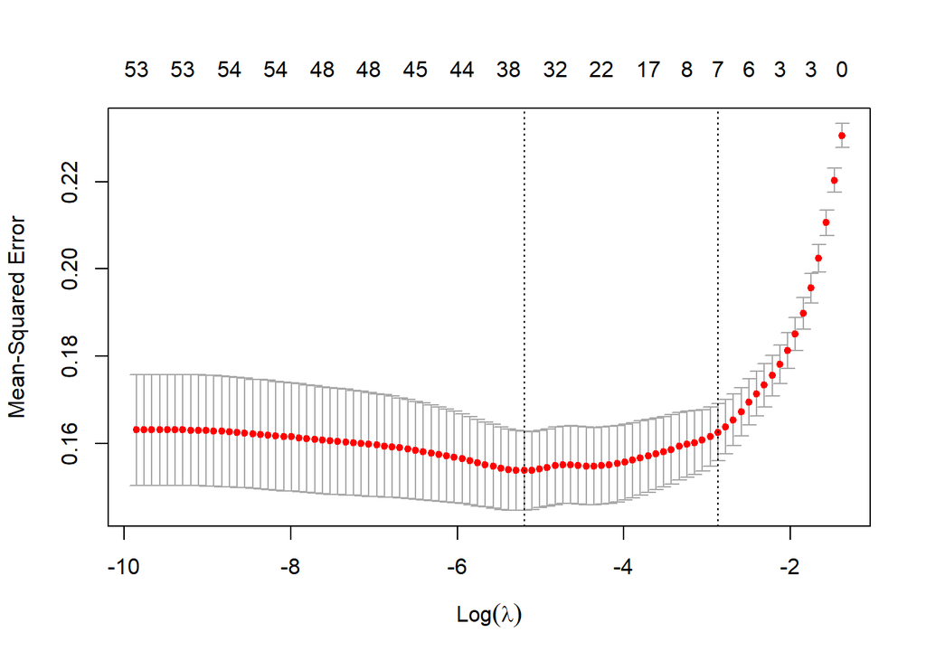

```r
label  <- sport_train$Label
label2 <- sport_test$Label
label3 <- sport_cv$Label
label  <- ifelse(label == "subjective", 1, 0)
label2 <- ifelse(label2 == "subjective", 1, 0)
label3 <- ifelse(label3 == "subjective", 1, 0)
label  <- as.matrix(label)
label2 <- as.matrix(label2)
label3 <- as.matrix(label3)
label_test <-label2
sport_train_lasso <- sport_train[,2:57]
sport_test_lasso <- sport_test[,2:57]
sport_cv_lasso <- sport_cv[,2:57]

#L1 penalty with different lamddas (0.01,0.1)

cv_sport <- cv.glmnet(as.matrix(sport_train_lasso),label, family = "gaussian")
lambda_min <- cv_sport$lambda.min
plot(cv_sport)
```

The best lambda is performed by using the 10-fold cross-validation for L1 penalty and it is found 0.005 which minimize the mean squared error as a metric performance.The different lambdas that changes the error of the dataset are used to evaluate penalized regression approach.

```r
lasso1 <- glmnet( as.matrix(sport_train_lasso),label, family='gaussian',lambda = lambda_min)
predict1<- predict(lasso1,as.matrix(sport_test_lasso))
predict_cv1 <- predict(lasso1,as.matrix(sport_cv_lasso))
mse_cv_lasso1 <- mse(predict_cv1,label3)
mse_lasso1 <- mse(predict1,label2)

lasso2 <- glmnet( as.matrix(sport_train_lasso),label, family='gaussian',lambda = 0.01)
predict2<- predict(lasso2,as.matrix(sport_test_lasso))
predict_cv2 <- predict(lasso2,as.matrix(sport_cv_lasso))
mse_cv_lasso2<- mse(predict_cv2,label3)
mse_lasso2 <- mse(predict2,label2)


lasso3 <- glmnet( as.matrix(sport_train_lasso),label, family='gaussian',lambda = 0.1)
predict3<- predict(lasso3,as.matrix(sport_test_lasso))
predict_cv3 <- predict(lasso3,as.matrix(sport_cv_lasso))
mse_cv_lasso3 <- mse(predict_cv3,label3)
mse_lasso3 <- mse(predict3,label2)


# Table
lambda_005<-c("0.005","0.150","0.132")
lambda_001<-c("0.01","0.147","0.133")
lambda_01<-c("0.1","0.166","0.187")
PRA_TABLE <-rbind(lambda_005,lambda_001,lambda_01)
PRA_TABLE<- as.data.frame(PRA_TABLE)
colnames(PRA_TABLE)<-c("lambda","cv error","test error")
PRA_TABLE
```

```
##            lambda cv error test error
## lambda_005  0.005    0.150      0.132
## lambda_001   0.01    0.147      0.133
## lambda_01     0.1    0.166      0.187
```

### DECISION TREE APPROACH

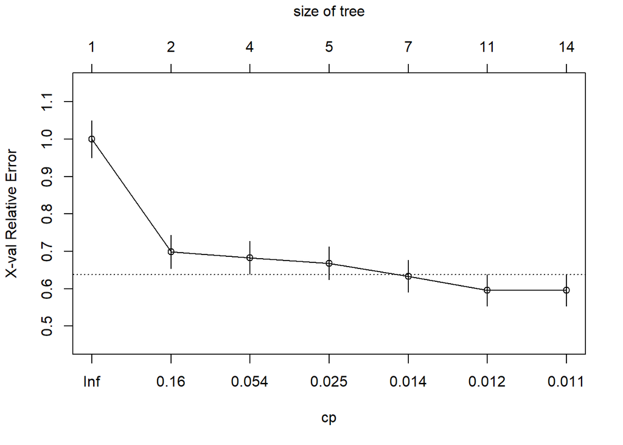

```r
sport_train_DT <- sport_train[,2:57]
sport_train_DT <- cbind(label,sport_train_DT)
sport_test_DT <- sport_test[,2:57]
sport_cv_DT <- sport_cv[,2:57]

cla_tree_1 = rpart(label~.,data = sport_train_DT,method = 'class')

plotcp(cla_tree_1)
```

```r
printcp(cla_tree_1)
```

```
##
## Classification tree:
## rpart(formula = label ~ ., data = sport_train_DT, method = "class")
##
## Variables actually used in tree construction:
##  [1] baseform      CD            compsupadjadv DT            LS
##  [6] PDT           present3rd    questionmarks Quotes        RP
## [11] txtcomplexity VBN
##
## Root node error: 262/720 = 0.36389
##
## n= 720
##
##         CP nsplit rel error  xerror     xstd
## 1 0.385496      0   1.00000 1.00000 0.049274
## 2 0.068702      1   0.61450 0.69847 0.044591
## 3 0.041985      3   0.47710 0.68321 0.044265
## 4 0.015267      4   0.43511 0.66794 0.043929
## 5 0.013359      6   0.40458 0.63359 0.043136
## 6 0.011450     10   0.35115 0.59542 0.042192
## 7 0.010000     13   0.31679 0.59542 0.042192
```

```r
cla_tree_1$variable.importance
```

```
##                LS        present3rd               VBP              PRP$
##       105.1805483        83.0439489        82.6508948        80.6631407
##               VBN               POS     questionmarks   totalWordsCount
##        79.3361753        70.3082714        26.0120596        19.2496482
##                CD                FW            Quotes          baseform
##        16.9970277        16.5663256        14.1456873        13.3136368
##                RP     txtcomplexity     present1st2nd            commas
##        11.8993261         9.9323702         8.8887846         7.7923228
##  semanticobjscore               PDT semanticsubjscore                MD
##         7.5464543         7.3805232         6.5925374         6.0237892
##                UH        imperative              NNPS                DT
##         5.5930225         5.4566073         3.2733273         2.9388889
##     compsupadjadv       pronouns2nd               JJR         fullstops
##         2.5928154         2.2858025         1.9592593         1.5199263
##                CC               SYM               WP$         semicolon
##         1.3994059         1.3994059         0.6766637         0.2656065
##                VB                WP
##         0.2656065         0.2656065
```

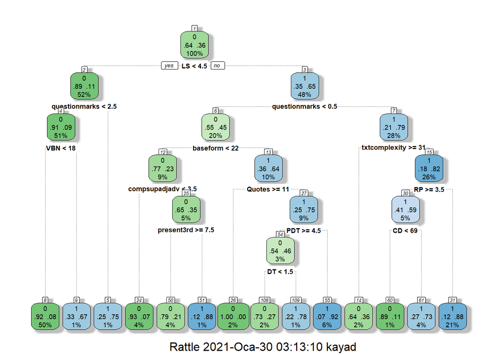

```r
fancyRpartPlot(cla_tree_1)
```

Decision tree approach is used for binary classification and best complexity parameter is obtained as a 0.012 that minimize the error and optimal tree size is found 11.The importance of variables is obtained to gain deeper information and interpret the model more easily.The complexity parameter and minimal number of observations per tree leaf( minsplit) are considered for model evaluation.

```r
mse_DT<-c()
mse_cv_DT<-c()
DT_TABLE <-matrix(0,4,12)
test_pred <- matrix(0,200,12)
cv_pred<- matrix(0,80,12)
cp <- c(0.01,0.05,0.1)
minsplit <- c(5,10,20,50)


i=1
   for(k in 1:length(minsplit)){
        for(l in 1:length(cp)){
 cla_tree <- rpart(label~.,data = sport_train_DT, method='class', control = rpart.control(cp = cp[l],minsplit = minsplit[k]))
 cla_tree_cv <- rpart(label~.,data = sport_train_DT, method='class', control = rpart.control(cp = cp[l],minsplit = minsplit[k]))
 testp <-predict(cla_tree, sport_test_DT, type = 'class')
 cv_p  <- predict(cla_tree_cv, sport_cv_DT, type = 'class')
 cv_pred[,i] <- as.numeric(as.character(cv_p))
 test_pred[,i] <- as.numeric(as.character(testp))
 test_label <- label2
 cv_label <- label3
 mse_cv_DT[i]<- mse(cv_pred[,i],cv_label)
 mse_DT[i] <- mse(test_pred[,i],test_label)
 DT_TABLE <- cbind(mse_DT,mse_cv_DT, minsplit,cp)
 i = i+1
        }
   }

DT_TABLE
```

```
##       mse_DT mse_cv_DT minsplit   cp
##  [1,]  0.185    0.2500        5 0.01
##  [2,]  0.175    0.2500       10 0.05
##  [3,]  0.255    0.3625       20 0.10
##  [4,]  0.185    0.2500       50 0.01
##  [5,]  0.175    0.2500        5 0.05
##  [6,]  0.255    0.3625       10 0.10
##  [7,]  0.175    0.2375       20 0.01
##  [8,]  0.175    0.2500       50 0.05
##  [9,]  0.255    0.3625        5 0.10
## [10,]  0.175    0.2250       10 0.01
## [11,]  0.175    0.2500       20 0.05
## [12,]  0.255    0.3625       50 0.10
```

### RANDOM FOREST APPROACH

```r
sport_train_DT$label <- as.factor(as.character(sport_train_DT$label))
sport_test <- cbind(label2,sport_test)
sport_test$label2 <- as.factor(as.character(sport_test$label2))
sport_test<-  subset(sport_test,select=-c(Label))


# mtry 10
rforest1<- randomForest(sport_train_DT[,2:57],sport_train_DT$label,ntree = 500 , nodesize = 5, mtry = 10)
rforest1_cv<-randomForest(sport_train_DT[,2:57],sport_train_DT$label,ntree = 500 , nodesize = 5, mtry = 10)
pred_cv_RF1<-predict(rforest1_cv,sport_cv[,2:57])
pred_cv_RF1<-as.numeric(as.character(pred_cv_RF1))
pred_RF1<-predict(rforest1,sport_test[,2:57])
pred_RF1<-as.numeric(as.character(pred_RF1))
mse_cv_RF1<- mse(pred_cv_RF1,cv_label)
mse_RF1 <- mse(pred_RF1,test_label)


# mtry 30

rforest2<- randomForest(sport_train_DT[,2:57],sport_train_DT$label,ntree = 500 , nodesize = 5, mtry = 30)
rforest2_cv<-randomForest(sport_train_DT[,2:57],sport_train_DT$label,ntree = 500 , nodesize = 5, mtry = 30)
pred_cv_RF2<-predict(rforest2_cv,sport_cv[,2:57])
pred_cv_RF2<-as.numeric(as.character(pred_cv_RF2))
pred_RF2<-predict(rforest2,sport_test[,2:57])
pred_RF2<-as.numeric(as.character(pred_RF2))
mse_cv_RF2<- mse(pred_cv_RF2,cv_label)
mse_RF2 <- mse(pred_RF2,test_label)

# mtry 5

rforest3<- randomForest(sport_train_DT[,2:57],sport_train_DT$label,ntree = 500 , nodesize = 5, mtry = 5)
rforest3_cv<-randomForest(sport_train_DT[,2:57],sport_train_DT$label,ntree = 500 , nodesize = 5, mtry = 5)
pred_cv_RF3<-predict(rforest3_cv,sport_cv[,2:57])
pred_cv_RF3<-as.numeric(as.character(pred_cv_RF3))
pred_RF3<-predict(rforest3,sport_test[,2:57])
pred_RF3<-as.numeric(as.character(pred_RF3))
mse_cv_RF3<- mse(pred_cv_RF3,cv_label)
mse_RF3 <- mse(pred_RF3,test_label)


# Table
mtry5<-c("5","0.187","0.155")
mtry10<-c("10","0.175","0.150")
mtry30<-c("30","0.15","0.145")
RF_TABLE <-rbind(mtry5,mtry10,mtry30)
RF_TABLE<- as.data.frame(RF_TABLE)
colnames(RF_TABLE)<-c("mtry","cv error","test error")
RF_TABLE
```

```
##        mtry cv error test error
## mtry5     5    0.187      0.155
## mtry10   10    0.175      0.150
## mtry30   30     0.15      0.145
```

The parameter that is used for model evaluation is the number of variables randomly sampled.When the number of features is increased, the error is slightly decreased.Since the variables are chosen randomly, it makes sense due to low number of important variables for sports article dataset.

### STOCHASTIC GRADIENT BOOSTING

```r
mse_cv_sgb <- c()
mse_sgb <- c()
pred_sgb <-matrix(0,200,27)
predcv_sgb<-matrix(0,80,27)
SGB_TABLE <- matrix(0,5,27)
shrinkage= c(0.01,0.1,0.5)
ntree=c(100,500,1000)
interaction_depth =c(1,2,3)

j=1
 for(m in 1:length(ntree)){
  for(n in 1:length(shrinkage)){
    for(p in 1:length(interaction_depth)){

 sgb <- gbm(label~.,data = sport_train_DT[,2:57],distribution ="bernoulli",n.trees = ntree[m],shrinkage = shrinkage[n], interaction.depth = interaction_depth[p])
 sgb_cv <- gbm(label~.,data = sport_train_DT[,2:57],distribution ="bernoulli",n.trees = ntree[m],shrinkage = shrinkage[n], interaction.depth = interaction_depth[p])
 pred_cv_sgb <-predict(sgb_cv,sport_cv[,2:57])
 pred_cv_sgb<-ifelse(pred_cv_sgb>0.50,"1","0")
 predcv_sgb[,j] <- as.numeric(as.character(pred_cv_sgb))
 pred_test_sgb <- predict(sgb,sport_test[,2:57])
 pred_test_sgb<-ifelse(pred_test_sgb>0.50,"1","0")
 pred_sgb[,j]<- as.numeric(as.character(pred_test_sgb))
 mse_cv_sgb[j] <-mse(predcv_sgb[,j],cv_label)
 mse_sgb[j]<- mse(pred_sgb[,j],test_label)
 SGB_TABLE <- cbind(mse_DT,mse_cv_DT, ntree,shrinkage,interaction_depth)
 j=j+1
    }
  }
 }

SGB_TABLE
```

```
##       mse_DT mse_cv_DT ntree shrinkage interaction_depth
##  [1,]  0.185    0.2500   100      0.01                 1
##  [2,]  0.175    0.2500   500      0.10                 2
##  [3,]  0.255    0.3625  1000      0.50                 3
##  [4,]  0.185    0.2500   100      0.01                 1
##  [5,]  0.175    0.2500   500      0.10                 2
##  [6,]  0.255    0.3625  1000      0.50                 3
##  [7,]  0.175    0.2375   100      0.01                 1
##  [8,]  0.175    0.2500   500      0.10                 2
##  [9,]  0.255    0.3625  1000      0.50                 3
## [10,]  0.175    0.2250   100      0.01                 1
## [11,]  0.175    0.2500   500      0.10                 2
## [12,]  0.255    0.3625  1000      0.50                 3
```

The best result obtained with penalized regression approach.Decision trees can be failed to deal with linear relationships. If there is any linear relationship between an input feature and the outcome , it can be considered or there is an error to implementation of algorithms.